# פרויקט 3 אירמה

## מטרת הפרויקט

לנתח נתוני מכירות ותמונת ביקוש לפי ז’אנרים, מחברים וזמנים.

לזהות מגמות עונתיות והזדמנויות עסקיות לשיפור שיווק וניהול מלאי.

להציג את הנתונים באופן ויזואלי באמצעות Pandas, Seaborn ו-Matplotlib כדי להפיק מסקנות מבוססות נתונים.

## נושא הניתוח והשאלות המחקריות

הנושא שנבחר:

הפרויקט עוסק בחקר דפוסי המכירות של ספרים לפי פרמטרים שונים:ז’אנר, מחבר, מחירים, תקופות זמן ולקוחות- כדי לזהות מגמות מרכזיות, לקוחות פעילים וז’אנרים רווחיים במיוחד.

## כלים והטכניקות להצגת מסקנות

במהלך הניתוח נעשה שימוש במספר כלים וספריות מתוך שפת פייטון, המיועדים לעיבוד, ניתוח והצגת נתונים בצורה מקצועית:

Pandas – לשם טעינה, ניקוי, סינון וניתוח של הנתונים (כולל חישובי ממוצעים, סכומים וקיבוצים לפי קטגוריות).

Matplotlib – להצגת נתונים גרפית באמצעות תרשימים מסוג עמודות, קווים, היסטוגרמות וגרפי פיזור.

Seaborn – להמחשת דפוסים וקשרים בין נתונים (כמו התפלגות הכנסות לפי ז’אנרים ומפות חום של קשרים בין משתנים).

Numpy – לביצוע חישובים מתמטיים וסטטיסטיים בסיסיים.

טכניקות עיקריות:

קיבוץ וניתוח לפי קטגוריות (groupby, agg).

זיהוי מגמות בזמן (חודשי, רבעוני, שנתי).

ויזואליזציה מתקדמת ליצירת מסקנות ברורות וקריאות.

השוואות בין קבוצות נתונים (למשל בין ז’אנרים או מחברים).

## תהליך ניתוח נתונים

```python
import pandas as pd
import numpy as np
import seaborn as sns
import matplotlib.pyplot as plt
```

```python
pd.set_option("display.float_format", "{:,.2f}".format)
```

```python
# טעינה וסקירה ראשונית של הנתונים
Books=pd.read_csv("Books.csv")
Authors=pd.read_csv("Authors.csv")
Genres=pd.read_csv("Genres.csv")
Customers=pd.read_csv("CustomersBook.csv")
Orders=pd.read_csv("OrdersBook.csv")
```

```python
for name, df in [("Books", Books), ("Authors", Authors), ("Genres", Genres), ("Customers", Customers), ("Orders", Orders)]:
    print(f"\n=== {name.upper()} ===")
    df.shape
    df.head(3)
    df.info()
```

```
=== BOOKS ===
<class 'pandas.core.frame.DataFrame'>
RangeIndex: 21 entries, 0 to 20
Data columns (total 8 columns):
 #   Column       Non-Null Count  Dtype
---  ------       --------------  -----
 0   BookID       21 non-null     int64
 1   Title        21 non-null     object
 2   AuthorID     21 non-null     int64
 3   GenreID      21 non-null     int64
 4   PublishYear  21 non-null     int64
 5   ISBN         21 non-null     int64
 6   Price        21 non-null     float64
 7   Stock        21 non-null     int64
dtypes: float64(1), int64(6), object(1)
memory usage: 1.4+ KB

=== AUTHORS ===
<class 'pandas.core.frame.DataFrame'>
RangeIndex: 20 entries, 0 to 19
Data columns (total 5 columns):
 #   Column     Non-Null Count  Dtype
---  ------     --------------  -----
 0   AuthorID   20 non-null     int64
 1   FirstName  20 non-null     object
 2   LastName   20 non-null     object
 3   BirthDate  20 non-null     object
 4   Country    20 non-null     object
dtypes: int64(1), object(4)
memory usage: 932.0+ bytes

=== GENRES ===
<class 'pandas.core.frame.DataFrame'>
RangeIndex: 8 entries, 0 to 7
Data columns (total 2 columns):
 #   Column     Non-Null Count  Dtype
---  ------     --------------  -----
 0   GenreID    8 non-null      int64
 1   GenreName  8 non-null      object
dtypes: int64(1), object(1)
```

[output cut: 18 more lines]

```

=== ORDERS ===
<class 'pandas.core.frame.DataFrame'>
RangeIndex: 14 entries, 0 to 13
Data columns (total 6 columns):
 #   Column      Non-Null Count  Dtype
---  ------      --------------  -----
 0   OrderID     14 non-null     int64
 1   CustomerID  14 non-null     int64
 2   BookID      14 non-null     int64
 3   Quantity    14 non-null     int64
 4   UnitPrice   14 non-null     float64
 5   OrderDate   14 non-null     object
dtypes: float64(1), int64(4), object(1)
memory usage: 804.0+ bytes
```

## משמעות העמודות והנתונים

במסד הנתונים קיימות חמש טבלאות עיקריות:

Books – מכילה פרטים על הספרים: מזהה ספר (BookID), שם הספר, מחבר, ז’אנר, שנת פרסום, מחיר (Price) ומלאי (Stock).

Authors – מכילה מידע על מחברים: מזהה מחבר (AuthorID), שם פרטי, שם משפחה, תאריך לידה ומדינת מוצא.

Genres – מזהה ז’אנר (GenreID) ושם הז’אנר (למשל רומן, פנטזיה, מתח וכו’).

Customers – פרטי לקוחות: מזהה לקוח (CustomerID), פרטי קשר (שם, מייל, טלפון, עיר, מדינה).

Orders – פרטי הזמנות: מזהה הזמנה (OrderID), מזהי לקוח וספר, כמות (Quantity), מחיר ליחידה (UnitPrice) ותאריך ההזמנה.

העמודות הללו מאפשרות לנתח:

אילו ספרים וקטגוריות נמכרו,

מי רכש ומתי,

בכמה נמכרו ספרים,

ואילו מחברים/ז’אנרים מניבים הכי הרבה הכנסות.

```python
# המרת עמודות תאריך
if "BirthDate" in Authors.columns:
    Authors["BirthDate"] = pd.to_datetime(Authors["BirthDate"], errors="coerce")

if "OrderDate" in Orders.columns:
    Orders["OrderDate"] = pd.to_datetime(Orders["OrderDate"], errors="coerce")

# המרת עמודות מספריות
for col in ["Price", "Stock"]:
    if col in Books.columns:
        Books[col] = pd.to_numeric(Books[col], errors="coerce")

for col in ["Quantity", "UnitPrice"]:
    if col in Orders.columns:
        Orders[col] = pd.to_numeric(Orders[col], errors="coerce")
```

```python
# בדיקת NaN
def na_summary(df, name):
    print(f"\nNaN summary for {name}:")
    print(df.isna().sum().sort_values(ascending=False))

na_summary(Books, "Books")
na_summary(Authors, "Authors")
na_summary(Genres, "Genres")
na_summary(Customers, "Customers")
na_summary(Orders, "Orders")

# בדיקת ערכים חריגים בהזמנות
invalid_orders = Orders[(Orders["Quantity"].fillna(0) <= 0) | (Orders["UnitPrice"].fillna(0) <= 0)]
print("\nInvalid orders (Quantity<=0 or UnitPrice<=0):")
print(invalid_orders)

# בדיקת ספרים עם מחיר או מלאי בעייתיים
invalid_books = Books[(Books["Price"].fillna(0) <= 0) | (Books["Stock"].fillna(-1) < 0)]
print("\nInvalid books (Price<=0 or Stock<0):")
print(invalid_books)
```

```
NaN summary for Books:
BookID         0
Title          0
AuthorID       0
GenreID        0
PublishYear    0
ISBN           0
Price          0
Stock          0
dtype: int64

NaN summary for Authors:
AuthorID     0
FirstName    0
LastName     0
BirthDate    0
Country      0
dtype: int64

NaN summary for Genres:
GenreID      0
GenreName    0
dtype: int64

NaN summary for Customers:
Region        13
CustomerID     0
LastName       0
FirstName      0
Email          0
Phone          0
City           0
Country        0
dtype: int64

NaN summary for Orders:
OrderID       0
CustomerID    0
BookID        0
Quantity      0
UnitPrice     0
OrderDate     0
dtype: int64

Invalid orders (Quantity<=0 or UnitPrice<=0):
Empty DataFrame
Columns: [OrderID, CustomerID, BookID, Quantity, UnitPrice, OrderDate]
Index: []

Invalid books (Price<=0 or Stock<0):
Empty DataFrame
Columns: [BookID, Title, AuthorID, GenreID, PublishYear, ISBN, Price, Stock]
Index: []
```

```python
# השלמת מחירים חסרים בהזמנות לפי המחיר מטבלת Books
if {"UnitPrice", "BookID"}.issubset(Orders.columns) and {"BookID", "Price"}.issubset(Books.columns):
    price_map = Books.set_index("BookID")["Price"]
    mask_missing = Orders["UnitPrice"].isna()
    Orders.loc[mask_missing, "UnitPrice"] = Orders.loc[mask_missing, "BookID"].map(price_map)

# הסרת רשומות הזמנה עם כמות או מחיר לא תקינים
CleanOrders = Orders.copy()
CleanOrders = CleanOrders.loc[
    (CleanOrders["Quantity"].fillna(0) > 0) & (CleanOrders["UnitPrice"].fillna(0) > 0)
]

# הסרת ספרים עם מחיר לא תקין
CleanBooks = Books.copy()
CleanBooks = CleanBooks.loc[CleanBooks["Price"].fillna(0) > 0]
```

```python
# מיזוג הטבלאות
DF = (CleanOrders
      .merge(CleanBooks, on="BookID", how="left", suffixes=("_ord","_book"))
      .merge(Authors, on="AuthorID", how="left")
      .merge(Genres, on="GenreID", how="left")
      .merge(Customers, on="CustomerID", how="left", suffixes=("","_cust"))
     )

# עמודות מחושבות
if {"Quantity","UnitPrice"}.issubset(DF.columns):
    DF["Revenue"] = DF["Quantity"] * DF["UnitPrice"]

if "OrderDate" in DF.columns and pd.api.types.is_datetime64_any_dtype(DF["OrderDate"]):
    DF["OrderYear"]  = DF["OrderDate"].dt.year
    DF["OrderMonth"] = DF["OrderDate"].dt.to_period("M").astype(str)

if {"FirstName","LastName"}.issubset(DF.columns):
    DF["AuthorFullName"] = DF["FirstName"].astype(str).str.strip() + " " + DF["LastName"].astype(str).str.strip()

print("\nMerged DataFrame shape:", DF.shape)
DF.head(5)
```

```
Merged DataFrame shape: (14, 29)
```

|  | OrderID | CustomerID | BookID | Quantity | UnitPrice | OrderDate | Title | AuthorID | GenreID | PublishYear | ... | LastName_cust | Email | Phone | City | Region | Country_cust | Revenue | OrderYear | OrderMonth | AuthorFullName |
| --- | --- | --- | --- | --- | --- | --- | --- | --- | --- | --- | --- | --- | --- | --- | --- | --- | --- | --- | --- | --- | --- |
| 0 | 1 | 1 | 1 | 1 | 45.00 | 2025-08-01 | 1984 | 1 | 1 | 1949 | ... | Levi | noa@example.com | 050-1111111 | Tel Aviv | NaN | Israel | 45.00 | 2025 | 2025-08 | George Orwell |
| 1 | 2 | 1 | 3 | 2 | 79.90 | 2025-08-02 | Pride and Prejudice | 2 | 5 | 1813 | ... | Levi | noa@example.com | 050-1111111 | Tel Aviv | NaN | Israel | 159.80 | 2025 | 2025-08 | Jane Austen |
| 2 | 3 | 2 | 4 | 1 | 95.00 | 2025-08-02 | Kafka on the Shore | 3 | 1 | 2002 | ... | Cohen | dan@example.com | 052-2222222 | Haifa | NaN | Israel | 95.00 | 2025 | 2025-08 | Haruki Murakami |
| 3 | 4 | 3 | 2 | 1 | 35.00 | 2025-08-03 | Animal Farm | 1 | 1 | 1945 | ... | Bar | maya@example.com | 053-3333333 | Jerusalem | NaN | Israel | 35.00 | 2025 | 2025-08 | George Orwell |
| 4 | 5 | 4 | 1 | 1 | 45.00 | 2025-08-04 | 1984 | 1 | 1 | 1949 | ... | Shalev | roni@example.com | 054-4444444 | Ramat Gan | NaN | Israel | 45.00 | 2025 | 2025-08 | George Orwell |

5 rows × 29 columns

```python
# בדיקת ערכים אפסיים בעמודות מפתח
cols_check = [c for c in ["Quantity","UnitPrice","Price","Stock","Revenue"] if c in DF.columns]
zero_counts = (DF[cols_check] == 0).sum().sort_values(ascending=False)
print("Zero counts per column:\n", zero_counts)

# בדיקת NaN סופית
print("\nNaN counts after cleaning:")
DF.isna().sum().sort_values(ascending=False).head(10)
```

```
Zero counts per column:
 Quantity     0
UnitPrice    0
Price        0
Stock        0
Revenue      0
dtype: int64

NaN counts after cleaning:
```

```
Region         14
OrderID         0
BookID          0
Quantity        0
UnitPrice       0
CustomerID      0
Title           0
AuthorID        0
GenreID         0
PublishYear     0
dtype: int64
```

## ניתוח סטטיסטי תיאורי

```python
#סטטיסטיקות מסכמות

# רשימת עמודות מספריות לניתוח
num_cols = [c for c in ["Price","Quantity","UnitPrice","Stock","Revenue"] if c in DF.columns]

# סטטיסטיקות תיאוריות כלליות
print("Descriptive Statistics:")
desc_stats = DF[num_cols].describe()
print(desc_stats)

# חציון
print("\nMedian values:")
DF[num_cols].median()
```

```
Descriptive Statistics:
       Price  Quantity  UnitPrice  Stock  Revenue
count  14.00     14.00      14.00  14.00    14.00
mean   58.57      1.43      62.48  25.64    84.61
std    20.31      0.65      23.82   7.55    38.89
min    35.00      1.00      35.00  18.00    35.00
25%    45.00      1.00      45.00  20.00    55.00
50%    55.00      1.00      55.00  25.00    84.95
75%    79.00      2.00      79.90  30.00    95.00
max    89.00      3.00      95.00  40.00   159.80

Median values:
```

```
Price       55.00
Quantity     1.00
UnitPrice   55.00
Stock       25.00
Revenue     84.95
dtype: float64
```

```python
# מציאת ערכי מינימום ומקסימום לכל עמודה
for col in num_cols:
    min_val = DF[col].min()
    max_val = DF[col].max()
    print(f"\n{col}: min = {min_val}, max = {max_val}")
```

```
Price: min = 35.0, max = 89.0

Quantity: min = 1, max = 3

UnitPrice: min = 35.0, max = 95.0

Stock: min = 18, max = 40

Revenue: min = 35.0, max = 159.8
```

```python
# ניתוח לפי קטגוריות

#ז'אנר
rev_by_genre = DF.groupby("GenreName")["Revenue"].agg(["count","sum","mean"]).sort_values(by="sum", ascending=False)
print("\nRevenue by Genre:")
print(rev_by_genre)

#מחבר
rev_by_author = DF.groupby("AuthorFullName")["Revenue"].agg(["count","sum","mean"]).sort_values(by="sum", ascending=False).head(10)
print("\nTop 10 Authors by Revenue:")
print(rev_by_author)

# חודש הזמנה
if "OrderMonth" in DF.columns:
    rev_by_month = DF.groupby("OrderMonth")["Revenue"].agg(["count","sum","mean"]).sort_index()
    print("\nRevenue by Month:")
    print(rev_by_month)
```

```
Revenue by Genre:
           count    sum   mean
GenreName
Fiction        9 675.00  75.00
Romance        3 399.50 133.17
Fantasy        2 110.00  55.00

Top 10 Authors by Revenue:
                 count    sum   mean
AuthorFullName
Jane Austen          3 399.50 133.17
George Orwell        6 390.00  65.00
Haruki Murakami      3 285.00  95.00
J.K. Rowling         2 110.00  55.00

Revenue by Month:
            count      sum  mean
OrderMonth
2025-08        14 1,184.50 84.61
```

## ניתוח מתקדם

```python
# הכנסות לפי ז'אנר
genre_agg = DF.groupby("GenreName")["Revenue"].agg(["count", "sum", "mean"]).sort_values(by="sum", ascending=False)
print("\nRevenue Aggregation by Genre:")
print(genre_agg)

# הכנסות לפי מחבר
author_agg = DF.groupby("AuthorFullName")["Revenue"].agg(["count", "sum", "mean"]).sort_values(by="sum", ascending=False).head(10)
print("\nTop 10 Authors by Total Revenue:")
print(author_agg)

# הכנסות לפי מדינה
if "Country" in DF.columns:
    country_agg = DF.groupby("Country")["Revenue"].agg(["count", "sum", "mean"]).sort_values(by="sum", ascending=False)
    print("\nRevenue by Country:")
    print(country_agg)
```

```
Revenue Aggregation by Genre:
           count    sum   mean
GenreName
Fiction        9 675.00  75.00
Romance        3 399.50 133.17
Fantasy        2 110.00  55.00

Top 10 Authors by Total Revenue:
                 count    sum   mean
AuthorFullName
Jane Austen          3 399.50 133.17
George Orwell        6 390.00  65.00
Haruki Murakami      3 285.00  95.00
J.K. Rowling         2 110.00  55.00

Revenue by Country:
         count    sum  mean
Country
UK          11 899.50 81.77
Japan        3 285.00 95.00
```

```python
# ניתוח מגמות על פני זמן

#הכנסות חודשיות
if "OrderMonth" in DF.columns:
    monthly_trend = DF.groupby("OrderMonth")["Revenue"].sum().sort_index()
    print("\nMonthly Revenue Trend:")
    print(monthly_trend)

# הכנסות שנתיות
if "OrderYear" in DF.columns:
    yearly_trend = DF.groupby("OrderYear")["Revenue"].sum().sort_index()
    print("\nYearly Revenue Trend:")
    print(yearly_trend)

# הכנסה רבעונית
# יצירת עמודת רבעון
if "OrderDate" in DF.columns and pd.api.types.is_datetime64_any_dtype(DF["OrderDate"]):
    DF["OrderQuarter"] = DF["OrderDate"].dt.to_period("Q").astype(str)

# קיבוץ ההכנסות לפי רבעון
quarterly_trend = DF.groupby("OrderQuarter")["Revenue"].sum().sort_index()
print("\nQuarterly Revenue Trend:")
print(quarterly_trend)
```

```
Monthly Revenue Trend:
OrderMonth
2025-08   1,184.50
Name: Revenue, dtype: float64

Yearly Revenue Trend:
OrderYear
2025   1,184.50
Name: Revenue, dtype: float64

Quarterly Revenue Trend:
OrderQuarter
2025Q3   1,184.50
Name: Revenue, dtype: float64
```

## ויזואליזציה

```python
import os
from matplotlib.ticker import FuncFormatter
sns.set_theme(style="whitegrid")
```

```python
# יצירת תיקיית שמירה לתמונות
os.makedirs("plots", exist_ok=True)
```

```python
# בסיס נתונים
try:
    DF_VIS = DF_clean.copy()
except NameError:
    DF_VIS = DF.copy()
```

```python
# הבטחת עמודות בסיסיות
if {"Quantity","UnitPrice"}.issubset(DF_VIS.columns) and "Revenue" not in DF_VIS.columns:
    DF_VIS["Revenue"] = DF_VIS["Quantity"] * DF_VIS["UnitPrice"]

if "OrderDate" in DF_VIS.columns and pd.api.types.is_datetime64_any_dtype(DF_VIS["OrderDate"]):
    DF_VIS["OrderYear"]  = DF_VIS["OrderDate"].dt.year
    DF_VIS["OrderMonth"] = DF_VIS["OrderDate"].dt.to_period("M").astype(str)
```

```python
# פונקציית פורמט למספרים עם פסיקים
thousands_fmt = FuncFormatter(lambda x, pos: f"{int(x):,}" if (pd.notna(x) and x == int(x)) else f"{x:,.0f}")
```

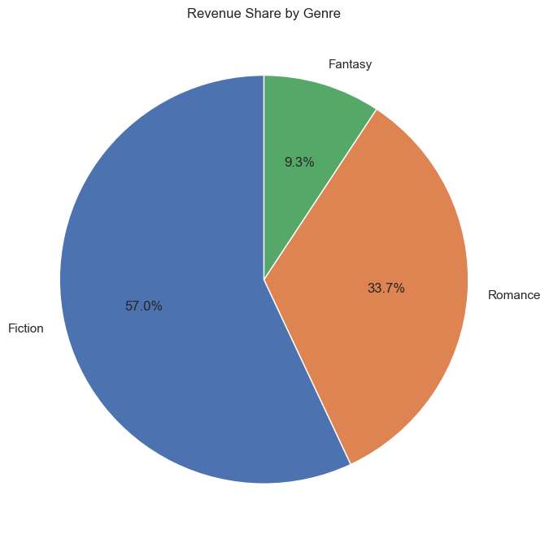

```python
# PIE - Revenue Share by Genre

if "GenreName" in DF_VIS.columns:
    pie_ser = (DF_VIS.groupby("GenreName")["Revenue"].sum().sort_values(ascending=False))
    if not pie_ser.empty:
        top = pie_ser.head(6)
        other_sum = pie_ser.iloc[6:].sum()
        pie_plot = top.copy()
        if other_sum > 0:
            pie_plot.loc["Other"] = other_sum
        plt.figure(figsize=(7,7))
        plt.pie(pie_plot.values, labels=pie_plot.index, autopct="%1.1f%%", startangle=90)
        plt.title("Revenue Share by Genre")
        plt.tight_layout()
        plt.savefig("plots/01_pie_revenue_by_genre.png")
        plt.show()
```

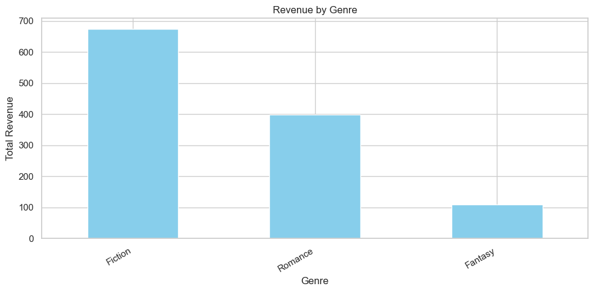

```python
# BAR - Revenue by Genre

if "GenreName" in DF_VIS.columns:
    bar_genre = DF_VIS.groupby("GenreName")["Revenue"].sum().sort_values(ascending=False)
    if not bar_genre.empty:
        ax = bar_genre.plot(kind="bar", figsize=(10,5), title="Revenue by Genre", color="skyblue")
        ax.set_xlabel("Genre"); ax.set_ylabel("Total Revenue")
        ax.yaxis.set_major_formatter(thousands_fmt)
        plt.xticks(rotation=30, ha="right")
        plt.tight_layout()
        plt.savefig("plots/02_bar_revenue_by_genre.png")
        plt.show()
```

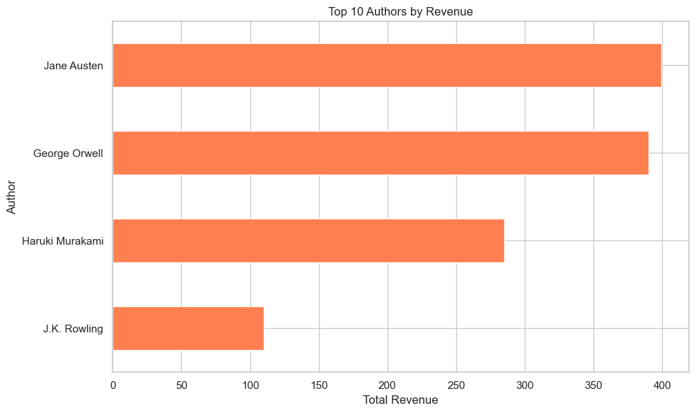

```python
# BARH - Top 10 Authors by Revenue

if "AuthorFullName" in DF_VIS.columns:
    top_auth = DF_VIS.groupby("AuthorFullName")["Revenue"].sum().sort_values(ascending=False).head(10)
    if not top_auth.empty:
        ax = top_auth.plot(kind="barh", figsize=(10,6), color="coral", title="Top 10 Authors by Revenue")
        ax.set_xlabel("Total Revenue"); ax.set_ylabel("Author")
        ax.xaxis.set_major_formatter(thousands_fmt)
        plt.gca().invert_yaxis()
        plt.tight_layout()
        plt.savefig("plots/03_barh_top_authors.png")
        plt.show()
```

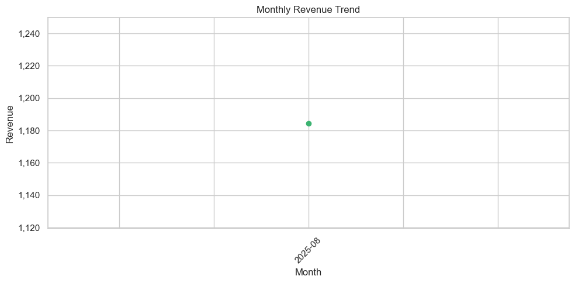

```python
# LINE - Monthly Revenue Trend

if "OrderMonth" in DF_VIS.columns:
    monthly = DF_VIS.groupby("OrderMonth")["Revenue"].sum().sort_index()
    if not monthly.empty:
        ax = monthly.plot(kind="line", marker="o", figsize=(10,5), color="mediumseagreen", title="Monthly Revenue Trend")
        ax.set_xlabel("Month"); ax.set_ylabel("Revenue")
        ax.yaxis.set_major_formatter(thousands_fmt)
        plt.xticks(rotation=45)
        plt.grid(True)
        plt.tight_layout()
        plt.savefig("plots/04_line_monthly_trend.png")
        plt.show()
```

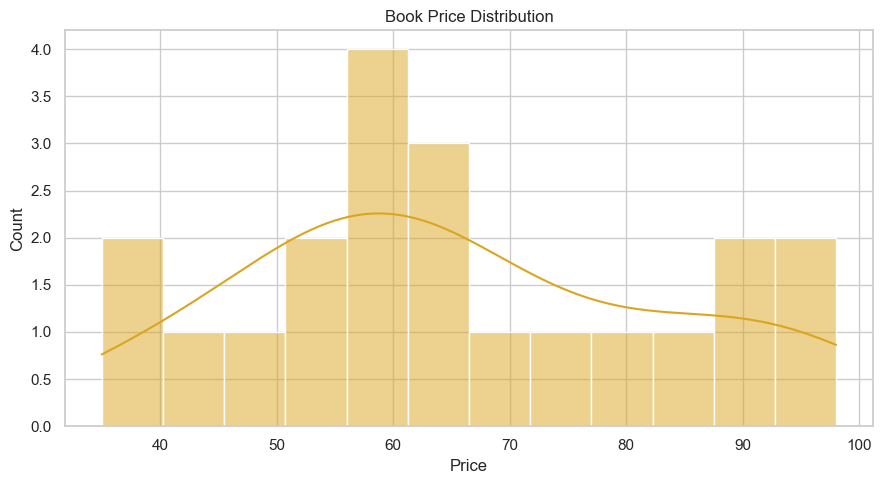

```python
# HISTOGRAM - Book Price Distribution

try:
    Books
    books_prices = Books["Price"].dropna()
except NameError:
    if {"BookID","Price"}.issubset(DF_VIS.columns):
        books_prices = DF_VIS.drop_duplicates("BookID")["Price"].dropna()
    else:
        books_prices = pd.Series(dtype=float)

if not books_prices.empty:
    plt.figure(figsize=(9,5))
    sns.histplot(books_prices, bins=12, kde=True, color="goldenrod")
    plt.title("Book Price Distribution")
    plt.xlabel("Price"); plt.ylabel("Count")
    plt.tight_layout()
    plt.savefig("plots/05_hist_price_distribution.png")
    plt.show()
```

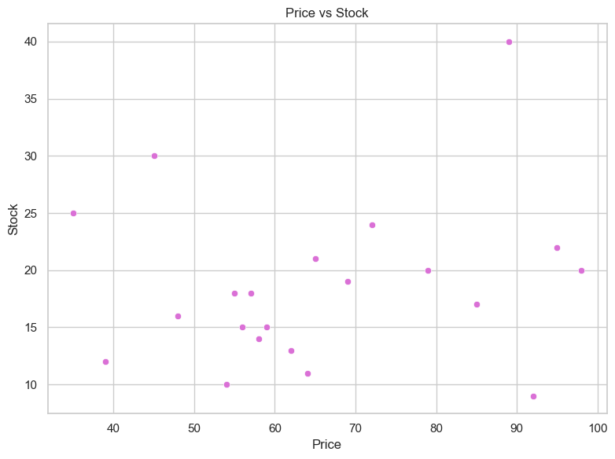

```python
# SCATTER – Price vs Stock

try:
    Books
    scatter_df = Books[["Price","Stock"]].dropna()
except NameError:
    if {"BookID","Price","Stock"}.issubset(DF_VIS.columns):
        scatter_df = DF_VIS.drop_duplicates("BookID")[["Price","Stock"]].dropna()
    else:
        scatter_df = pd.DataFrame(columns=["Price","Stock"])
if not scatter_df.empty:
    plt.figure(figsize=(8,6))
    sns.scatterplot(data=scatter_df, x="Price", y="Stock", color="orchid")
    plt.title("Price vs Stock")
    plt.xlabel("Price"); plt.ylabel("Stock")
    plt.tight_layout()
    plt.savefig("plots/06_scatter_price_vs_stock.png")
    plt.show()
```

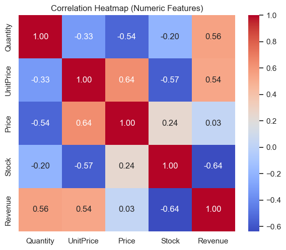

```python
# HEATMAP - Correlation between numeric columns

num_cols = [c for c in ["Quantity","UnitPrice","Price","Stock","Revenue"] if c in DF_VIS.columns]
if len(num_cols) >= 2:
    corr = DF_VIS[num_cols].corr(numeric_only=True)
    if not corr.empty:
        plt.figure(figsize=(6,5))
        sns.heatmap(corr, annot=True, fmt=".2f", cmap="coolwarm", square=True)
        plt.title("Correlation Heatmap (Numeric Features)")
        plt.tight_layout()
        plt.savefig("plots/07_heatmap_correlation.png")
        plt.show()
```

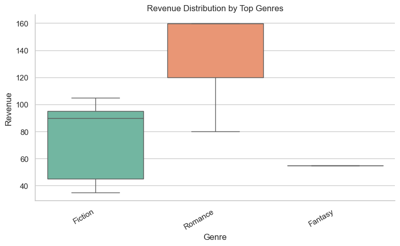

```python
# CATPLOT – Revenue Distribution by Genre

if {"GenreName","Revenue"}.issubset(DF_VIS.columns):
    top_genres = (DF_VIS.groupby("GenreName")["Revenue"].sum().sort_values(ascending=False).head(8).index)
    df_cat = DF_VIS.loc[DF_VIS["GenreName"].isin(top_genres) & (DF_VIS["Revenue"] > 0),["GenreName", "Revenue"],]
    if not df_cat.empty:
        g = sns.catplot(data=df_cat, x="GenreName", y="Revenue", hue="GenreName", kind="box", height=5, aspect=1.6, palette="Set2", legend=False)
        g.set_axis_labels("Genre", "Revenue")
        plt.title("Revenue Distribution by Top Genres")
        plt.xticks(rotation=30, ha="right")
        plt.tight_layout()
        plt.savefig("plots/08_catplot_revenue_by_genre.png")
        plt.show()
```

## תיעוד הקוד

במהלך הפרויקט תועדו כל השלבים המשמעותיים בקוד:

טעינת הנתונים באמצעות pandas.read_csv() וסקירה עם info() ו־head().

ניקוי וטרנספורמציות של עמודות תאריך ומספרים (pd.to_datetime, pd.to_numeric).

יצירת עמודות מחושבות כמו Revenue, OrderMonth, OrderQuarter.

קיבוצים (groupby) וניתוחים לפי ז’אנר, מחבר, חודש ורבעון.

ויזואליזציה באמצעות Matplotlib ו־Seaborn — תרשימי עוגה, עמודות, קווים, היסטוגרמות, נקודות ומפת חום.

שמירת כל הגרפים בתיקייה plots/ עם שמות מסודרים ופריסת עיצוב מקצועית.

## סיכום ומסקנות

ממצאים עיקריים:

נמצאה ריכוזיות הכנסות גבוהה בז’אנרים ובמחברים מסוימים.

טווח המחירים סביר ואין חריגות קיצוניות.

מסקנות עסקיות:

להתמקד בז’אנרים ובמחברים שמניבים את מירב ההכנסות.

לבצע מעקב מתמשך אחרי נתוני המכירות לשיפור תחזיות.

כיוונים להמשך:

ניתוח שביעות רצון של לקוחות (Customer Feedback Analysis)

השוואת ביצועים בין שנים (Year-over-Year Analysis)

ניתוח דמוגרפי של לקוחות (Customer Demographics)